# Princípios de modelagem matemática aplicadas à Pedometria

Alan R. Panosso

19/11/2020

# O R

- O sistema R é um ambiente que incorpora uma implementação da linguagem de programação S, desenvolvida por John Chambers et al. na Lucent Technologies em 1960.
- 1988: S-Plus é implementado o Software proprietário de análise de dados que contém a linguagem S.
- 1996: Linguagem orientada a objetos R (Ross Ihaka e Robert Gentleman).
- R é uma poderosa linguagem, flexível e possui excelentes facilidades gráficas.
- R é um projeto **open-source** e está disponível na internet sobre a General Public License (www.gnu.org/copyleft/gpl.html e www.fsf.org).

# Instalação do R (sistema base)

Baixe o R do site oficial The R Project for Statistical Computing https://www.r-project.org/

Acesso rápido: [Download](https://cran-r.c3sl.ufpr.br/bin/windows/base/R-4.0.3-win.exe)

Salve o arquivo de instalação em um diretório de seu computador e em seguida execute-o.

O processo é simples e intuitivo.

# Instalando o RStudio

É um ambiente de desenvolvimento integrado (IDE) para o R, disponível em https://rstudio.com/products/rstudio/download/

Escolha a o instalador de acordo com o seu sistema operacional. **Windows** no nosso caso.

Novamente, salve o arquivo de instalação em um diretório de seu computador e em seguida execute-o.

Após a instalação procure o ícone do R criado pelo instalador e clique nele.

# Pacotes no R (instalação dos pacotes)

Um pacote é uma coleção de funções, exemplos e documentação. A funcionalidade de um pacote é frequentemente focada em uma metodologia estatística especial" (**Everitt & Hothorn**).

[figure not shown]

### Utilizando a opção `Install/Packages`

Instale alguns pacotes:

- `tidyverse`
- `agricolae`
- `lawstat`
- `nortest`
- `lattice`
- `readxl`
- `stringr`
- `lubridate`

# Operações Básicas

### operação aritmética

```r
1 + 7 # cálculo da soma destes dois números
1 - 2 * 10 # prioridade da multiplicação
2 ** 10 # potências utilizando ** ou ^
10/3 # divisão
```

### funções encontradas em calculadoras científicas

$$\begin{aligned}
& a)\;\sqrt{9} = 3\\
& b)\;seno\;\pi = 0\\
& c)\;4! = 24\\
& d)\; e^5 = 148.4132
\end{aligned}$$

```r
sqrt(9) # raiz quadrada
sin(pi) # seno de Pi radianos é zero
factorial(4) #4!=4*3*2*1
exp(5) #exponencial de 5, e^5
```

### operações relacionais

$$\begin{aligned}
& a)\;7 > 5 \text{ retorna 'true'}\\
& b)\;8 \leq 4 \text{ retorna 'false'}\\
& c)\;5 = \frac{25}{5} \text{ retorna 'true'}\\
& d)\; 4\neq 8 \text{ retorna 'true'}
\end{aligned}$$

```r
7 > 5 # 7 é maior que 5 ?
8 <= 4 # 8 é menor ou igual a 4?
5 == 25/5 # igual a
4 != 8 # Diferente de
```

**Exercício 1**. Resolva as seguintes expressões:
$$\begin{aligned}
& a)\; log\;3 \\
& b)\; log_4\;3\\
& c)\; ln\;10\\
& d)\; e^2\\
& e)\; \sqrt(225)\\
& f)\; \frac{25+60\times8}{(14-5)^2}\\
& g)\; 8!\\
& h)\; seno\;30°\\
& i)\; \frac{1}{\sqrt{2\pi}}\cdot e^{-\frac{1}{2}\times4^2}\\
& j)\; \text{Gerar 3 números aleatórios}\\
\end{aligned}$$

# Principais objetos no R

## Escalar

É um objeto ao qual é atribuído um valor que pode ter qualquer um dos tipos, numérico, caractere, complexo ou lógico.

```r
x <- 10
"Maria" -> nome
res  <- (x==20)
```

```
  Quando uma estrutura de dados é composta de variáveis com o mesmo tipo primitivo, temos um conjunto  de dados homogêneo (vetores, fatores e matrizes).
```

## Vetor

É considerada a **forma mais simples de armazenamento de dados** em um objeto, são classificados como variáveis com **um ou mais valores do mesmo tipo**. Na verdade, um escalar para o R é definido como um vetor com um único elemento. Essa estrutura de dados tem o 1 como índice inicial. E podem ser referenciados por **[k]** onde k é a posição do elemento no vetor.

```r
z<-c(3,2,7,4,5)
z[3] # o elemento na posição 3 de z é o inteiro 7.
1:10
seq(0,100,25)
rep(1,10)
rep(1:3,4)
rep("testemunha",4)
x<-1:100
is.vector(x)
is.vector(z)
length(z)
```

```
Um conjunto heterogêneo de dados é composto por elementos que não são do mesmo tipo primitivo, como exemplo, temos os data.frames e as listas (ou registros).
```

## Data Frames

Os data.frames são considerados a **melhor forma de armazenar dados**, pois cada linha corresponde a uma unidade (observação), indivíduo ou pessoa, e cada coluna representa uma medida realizada em cada unidade (característica ou variáveis).

```r
alunos<-data.frame(
  RA=c(1933456,1935432,1869524),
  Nome=c("Maria Eduarda Ferreira","Paulo Antunes Arantes","Ricardo Luís Siqueira"),
  Média=c(9.5,7.75,4.8),
  Situação=c("Aprovado","Aprovado","Exame")
)
alunos
```

# Entrada de dados

## Lendo diretamente da Internet

```r
dados <- read.table("https://raw.githubusercontent.com/arpanosso/pedometria/main/dados/geomorfologia.txt",
                          h=TRUE,
                          sep="\t")
```

## Banco de dados em TXT

Faça o download do banco de dados geomorfologia.txt

```r
dados <- read.table("C:/R/geomorfologia.txt",h=TRUE,sep="\t")
```

## Banco de dados do Excel

Faça o download do banco de dados geomorfologia.xlsx

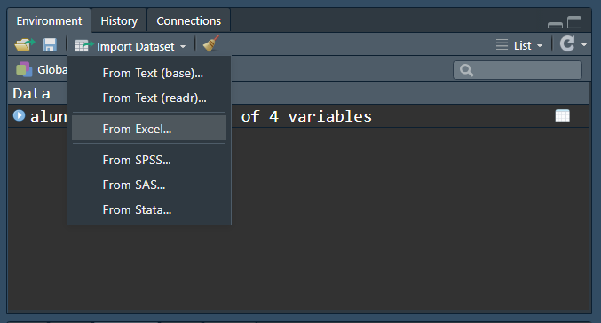

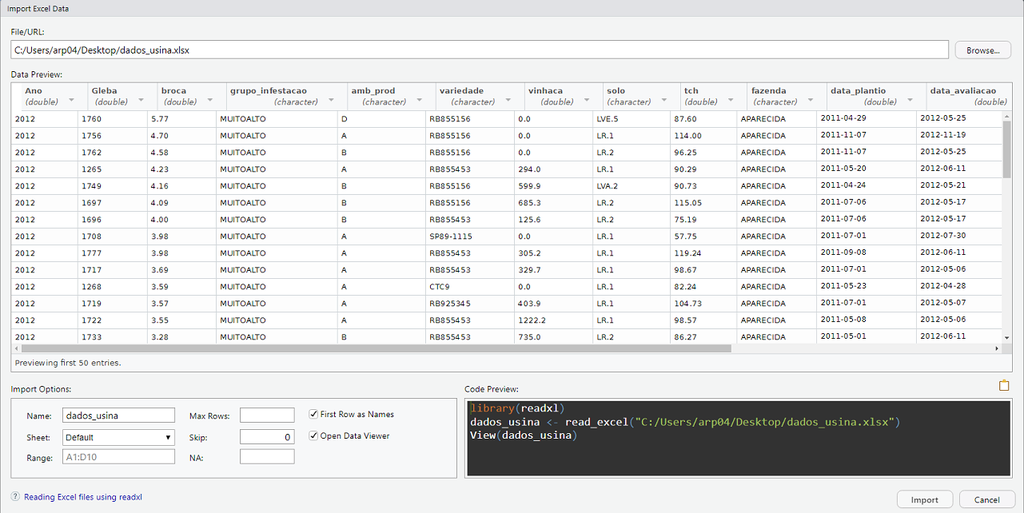

```r
library(readxl)
geomorfologia <- read_excel("dados/geomorfologia.xlsx")
View(geomorfologia)
```

# Manipulação dos dados

Para a manipulação dos nossos dados, vamos utilizar o pacote `dplyr`, que é um pacote específico para a manipulação de dados, unido ao pacote `ggplot2` é um poderoso recurso para exploração, transformação e visualização de dados. Ambos os pacotes fazem parte o `tidyverse`, que é um pacote de pacotes.

## Principais funções (verbos) do `dplyr`.

- `filter()`: seleciona/filtra por linhas (observações) a base de dados
- `arrange()`: ordena a base de dados de acordo com alguma coluna (variável)
- `select()`: seleciona colunas (variáveis)
- `mutate()`: modifica/transforma/cria variáveis (colunas)
- `summarise()`: resume/agrega, variáveis (colunas) de uma base de dados

## Regras para manipulação:

1- O primeiro argumento sempre será um `data.frame`.  
2- Demais argumentos, descrevem como deve ser a manipulação.  
3- A resposta sempre será um `data.frame`.  
4- Manipulação é realizada com o operador “PIPE” (`%>%`) - `CTRL SHIFT + M`.

### Carregando os pacotes

```r
library(tidyverse) # um pacote de pacotes...
```

**Exercício 2**. Execute a função `glimpse` para uma visão rápida a respeito das variáveis do banco de dados.

```
## Rows: 106
## Columns: 22
## $ SUP     <chr> "I", "I", "I", "I", "I", "I", "I", "I", "I", "I", "I", "I",...
## $ Solo    <chr> "LV", "LV", "LV", "LV", "LV", "LV", "LV", "LV", "LV", "LV",...
## $ Amostra <int> 1, 2, 3, 4, 5, 6, 7, 8, 9, 10, 11, 12, 13, 14, 15, 16, 17, ...
## $ X       <int> 0, 25, 50, 75, 100, 125, 150, 175, 200, 225, 250, 275, 300,...
## $ AMG     <dbl> 0.2, 0.1, 0.7, 0.4, 0.4, 0.4, 1.2, 0.8, 1.1, 1.2, 0.1, 0.2,...
## $ AG      <dbl> 3.72, 4.27, 5.00, 3.80, 3.10, 3.80, 3.60, 4.70, 4.50, 5.90,...
## $ AM      <dbl> 20.4, 22.6, 22.7, 23.7, 22.3, 23.8, 23.1, 25.8, 25.5, 32.8,...
## $ AF      <dbl> 22.9, 23.6, 22.2, 24.4, 24.6, 19.1, 21.7, 21.1, 18.9, 19.8,...
## $ AMF     <dbl> 30.0, 28.4, 26.9, 26.7, 26.9, 27.1, 26.5, 24.7, 25.4, 21.7,...
## $ SILTE   <dbl> 1.2, 1.2, 1.2, 0.6, 2.1, 2.2, 0.7, 0.2, 2.5, 0.2, 2.5, 2.6,...
## $ ARGILA  <dbl> 21.5, 20.4, 21.4, 20.5, 20.7, 23.5, 23.1, 22.7, 22.0, 18.5,...
## $ S_A     <dbl> 0.05, 0.05, 0.05, 0.02, 0.10, 0.09, 0.03, 0.01, 0.11, 0.01,...
## $ AF_AG   <dbl> 6.16, 5.53, 4.44, 6.42, 7.94, 5.03, 6.03, 4.49, 4.20, 3.36,...
## $ P       <int> 42, 22, 41, 27, 11, 12, 11, 16, 38, 25, 25, 6, 6, 7, 5, 4, ...
## $ pH      <dbl> 4.2, 3.8, 4.8, 4.0, 4.4, 4.0, 4.8, 5.4, 4.4, 5.2, 4.5, 5.1,...
## $ K       <dbl> 0.27, 0.11, 0.34, 0.13, 0.11, 0.14, 0.23, 0.28, 0.19, 0.14,...
## $ Ca      <dbl> 1.4, 0.4, 2.4, 0.7, 1.4, 0.6, 1.6, 3.3, 1.6, 2.9, 1.3, 1.6,...
## $ Mg      <dbl> 0.3, 0.1, 0.4, 0.1, 0.3, 0.1, 0.7, 1.3, 0.5, 1.7, 0.6, 0.8,...
## $ H_Al    <dbl> 5.2, 5.8, 4.2, 5.2, 4.2, 5.2, 3.4, 2.5, 5.2, 3.1, 4.2, 2.5,...
## $ SB      <dbl> 1.97, 0.61, 3.14, 0.93, 1.81, 0.84, 2.53, 4.88, 2.29, 4.74,...
## $ T       <dbl> 7.17, 6.41, 7.34, 6.13, 6.01, 6.04, 5.93, 7.38, 7.49, 7.84,...
## $ V       <int> 27, 10, 43, 15, 30, 14, 43, 66, 31, 60, 32, 50, 22, 35, 36,...
```

**Exercício 3**. Selecione as **linhas** para superfície igual a “II”.

```r
dados %>%
  filter(SUP == "II")
```

```r
df<-dados %>%
  filter(ARGILA > 10, SUP == "III")
```

**Exercício 5**. Desse novo objeto, selecione todas as observações que não pertençam ao solo “R”.

```r
df %>%
  filter(Solo != "R")
```

**Exercício 6**. Dos dados originais faça uma contagem de quantos pontos existem em cada uma dessas superfícies.

```r
dados %>%
  group_by(SUP) %>%
  count(SUP)
```

**Exercício 7**. Selecione todos os Latossolos?

```r
library(stringr)
dados %>%
  filter(str_detect(Solo,"^L"))
levels(as.factor(dados$Solo))
```

**Exercício 8**. Selecione os registros cujo solo é “PV4”?

```r
dados %>%
  filter(str_detect(Solo,"PV4"))
```

**Exercício 9**. Selecione os registros cujo nome do solo termina com o “p”?

```r
dados %>%
  filter(str_detect(Solo,"p$"))
```

**Exercício 10**. Ordene os registros por ordem crescente de teor de ARGILA

```r
dados %>%
  arrange(ARGILA)
```

**Exercício 11**. Ordene os registros por ordem decrescente de “H_Al”.

```r
dados %>%
  arrange(desc(H_Al))
```

**Exercício 12**. Calcule a soma dos teores de ARGILA + SILTE, em seguida transforme o teor de fósforo para a escala logarítmica.

```r
dados %>%
  mutate(
    ARG_SILT = ARGILA + SILTE,
    log_P = log10(P)
  )
```

**Exercício 13**. Classifique a Textura do solo.

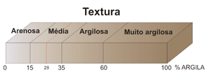

```r
range(dados$ARGILA)
dados %>%
  mutate(
    TEXTURA = case_when(
      ARGILA < 15 ~ "Arenosa",
      ARGILA <= 35 ~ "Media",
      ARGILA <= 60 ~ "Argilosa",
      ARGILA > 60 ~ "Muito argilosa",
      TRUE ~ "Sem classificação")
  )
```

**Exercício 14**. Calcule as estatísticas descritivas para alguns atributos do solo de sua preferência.

```r
library(agricolae)
dados %>%
  group_by(SUP) %>%
  summarise(N=length(Ca),
            media = mean(Ca),
            mediana =median(Ca)
  )
```

## Gráficos usando o ggplot2

**Exercício 15**. Construa um gráfico de dispersão entre P e Ca.

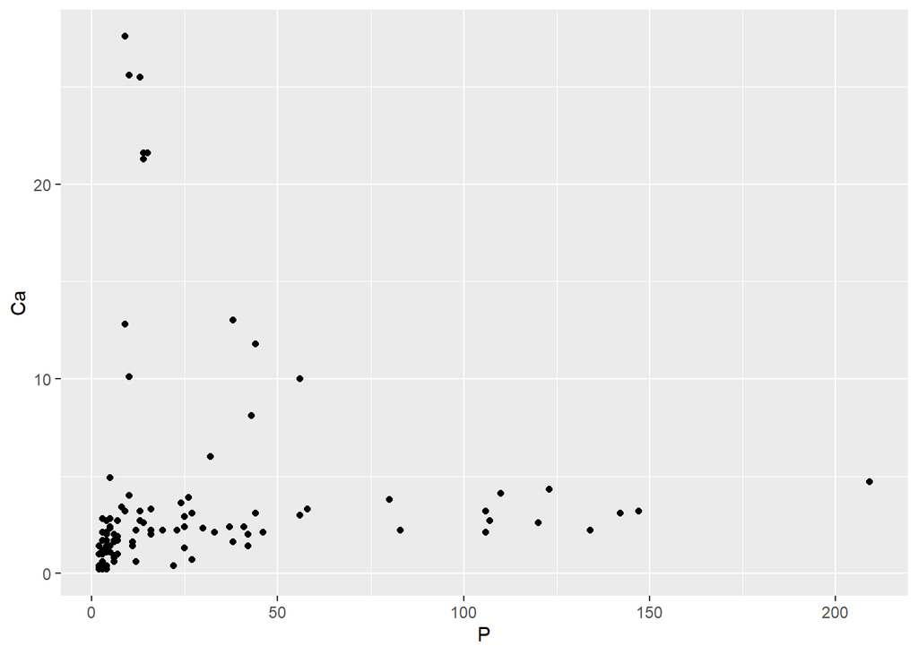

```r
# chamar os dados
# filtrar, agrupar, gerar estatísticas se necessário
# adicionar as camadas gráficas

# Gráfico de Dispersão
dados %>%
  ggplot(aes(x=P,y=Ca) ) + # dizer quem será o x e o y dentro de aes
  geom_point()
```

**Exercício 16**. Construa um gráfico de dispersão entre a ARGILA e SILTE do ar, mapeie as Superfícies por meio das cores no novo gráfico.

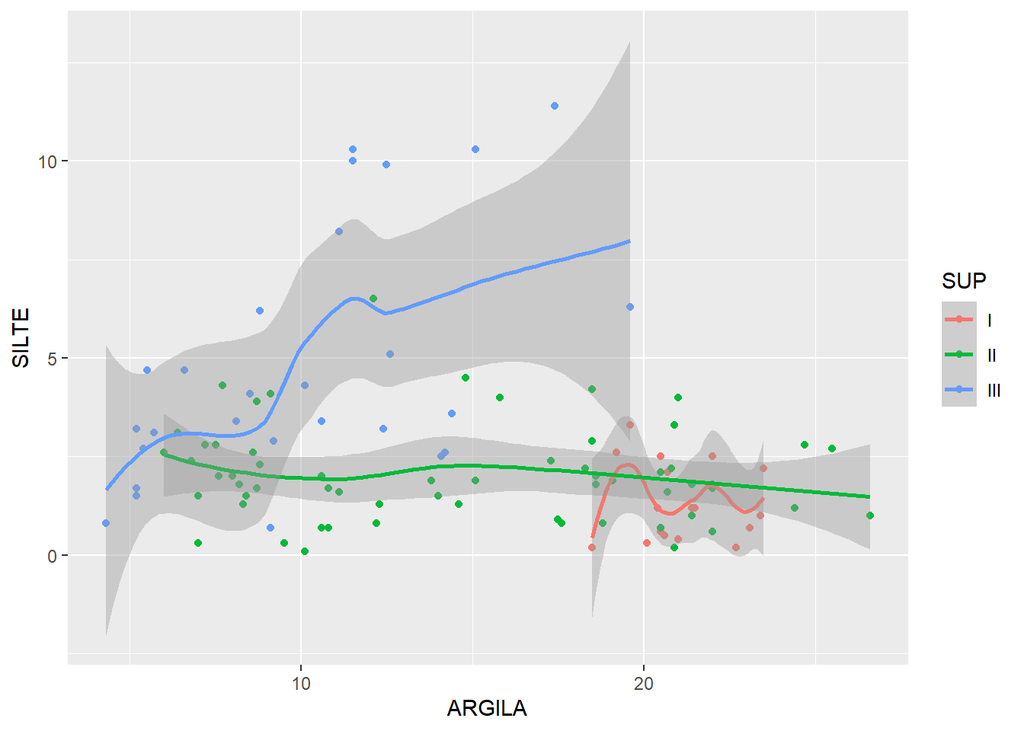

```r
# Gráfico de Dispersão
dados %>%
  ggplot(aes(x=ARGILA,y=SILTE,color=SUP) ) + # dizer quem será o x e o y dentro de aes
  geom_point()+
  geom_smooth(aes(x=ARGILA,y=SILTE))
```

**Exercício 17**. Construa um gráfico de dispersão entre a ARGILA e SILTE, mapeie as Superfícies por meio das formas dos marcadores no novo gráfico.

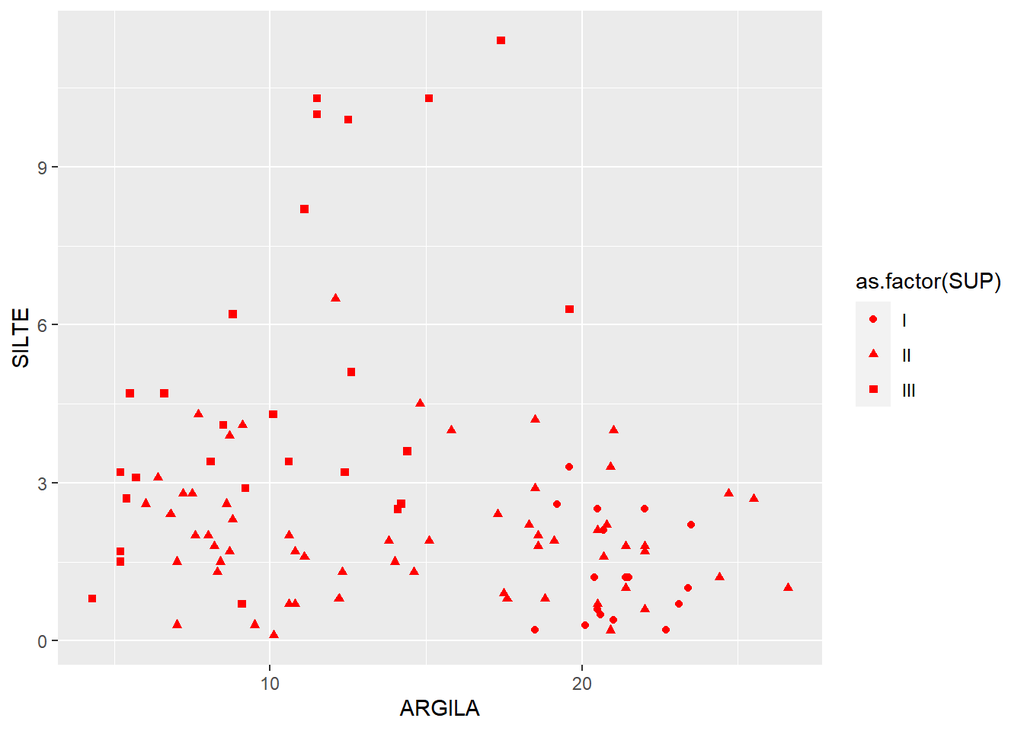

```r
dados %>%
  ggplot(aes(x=ARGILA,y=SILTE)) +
  geom_point(aes(shape=as.factor(SUP)),color="red")
```

**Exercício 18**. Adicione os títulos dos gráficos, eixos e legendas.

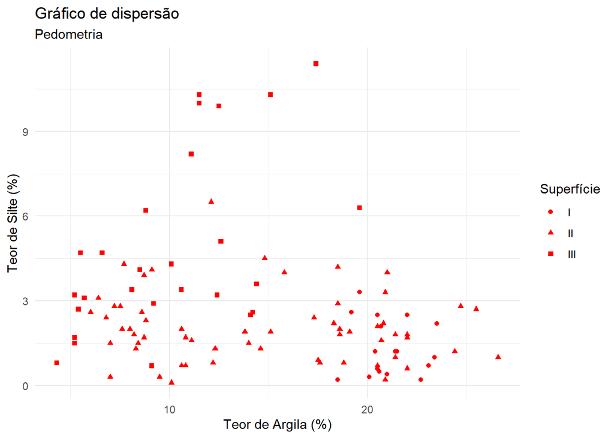

```r
dados %>%
  ggplot(aes(x=ARGILA,y=SILTE) ) + # dizer quem será o x e o y dentro de aes
  geom_point(aes(shape=as.factor(SUP)),color="red")+
  theme_minimal()+
  labs(x="Teor de Argila (%)",y="Teor de Silte (%)",shape="Superfície") +
  ggtitle("Gráfico de dispersão",subtitle = "Pedometria")
```

**Exercício 19**. Criar um gráfico de barras, com os solos presentes na superfície “III”.

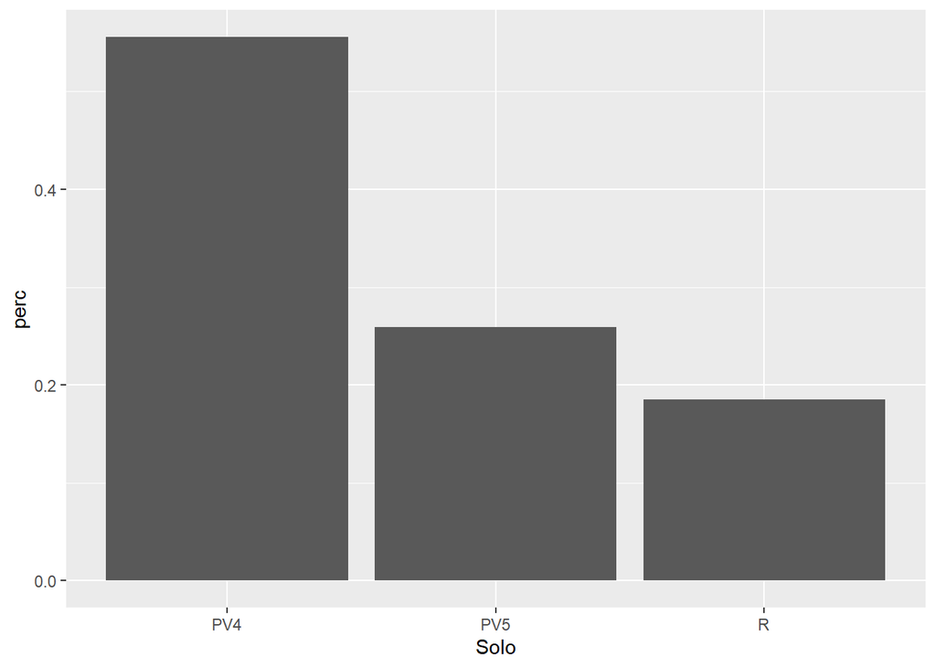

```r
dados %>%
  filter(SUP=="III") %>%
  group_by(Solo) %>%
  summarise(n=n()) %>%
  mutate(perc=n/sum(n)) %>%
  ggplot(aes(x=Solo, y=perc))+
  geom_col()
```

**Exercício 20**. Altere os eixos as cores do gráfico anterior.

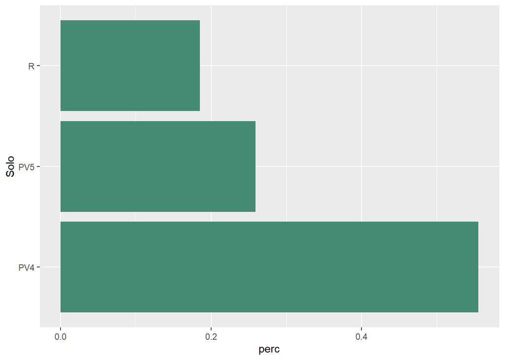

```r
# Gráfico de Barras
dados %>%
  filter(SUP=="III") %>%
  group_by(Solo) %>%
  summarise(n=n()) %>%
  mutate(perc=n/sum(n)) %>%
  ggplot(aes(x=Solo, y=perc))+
  geom_col(fill="aquamarine4") +
  coord_flip()
```

**Exercício 21**. Ordene o banco de dados dos Solos mais observados para os menos observados.

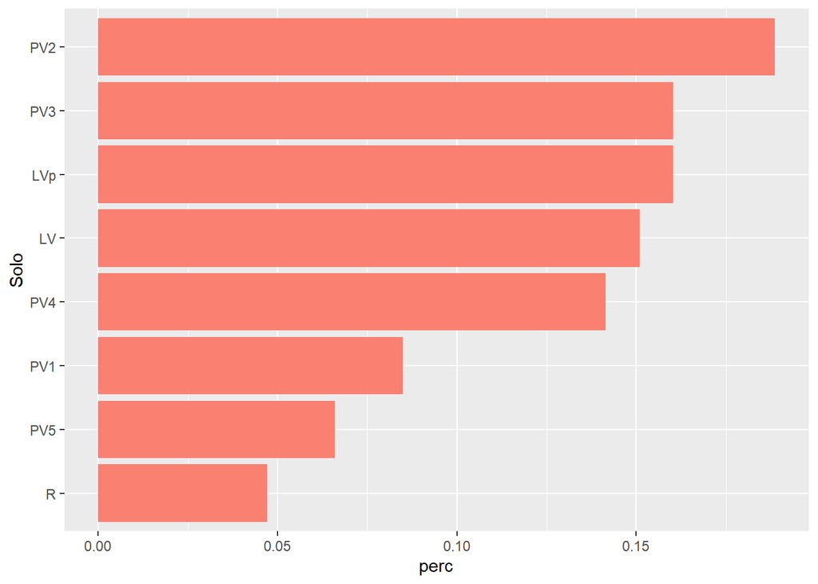

```r
# Gráfico de Barras
dados %>%
  group_by(Solo) %>%
  summarise(n=n()) %>%
  mutate(perc=n/sum(n),
         Solo = Solo %>% fct_lump(n=10,w=perc) %>% fct_reorder(perc)) %>%
  ggplot(aes(x=Solo, y=perc))+
  geom_col(fill="salmon") +
  coord_flip()
```

**Exercício 22**. Criar o gráfico de colunas para as médias de Teor de ARGILA para cada Solo.

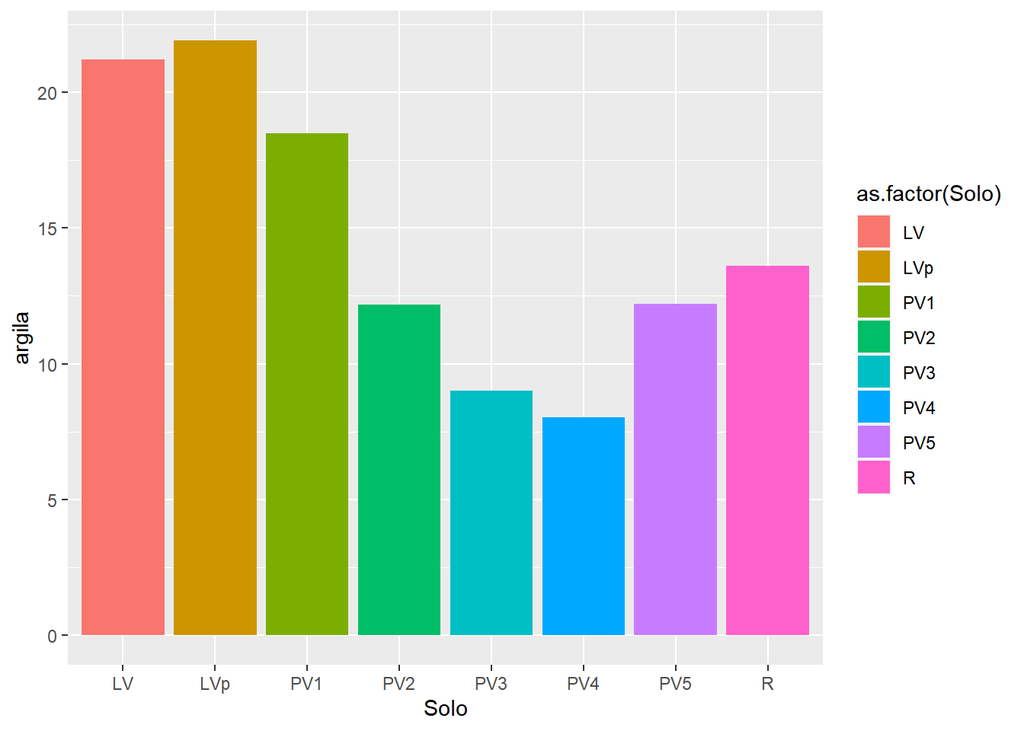

```r
dados %>%
  group_by( Solo) %>%
  summarise(argila=mean(ARGILA)) %>%
  ggplot(aes(x=Solo,y=argila,fill=as.factor(Solo))) +
#  geom_col(position = "stack") +
  geom_col(position = "dodge")
```

**Exercício 23**. Adicione a linha de tendência linear entre ARGILA e SILTE para cada SUP.

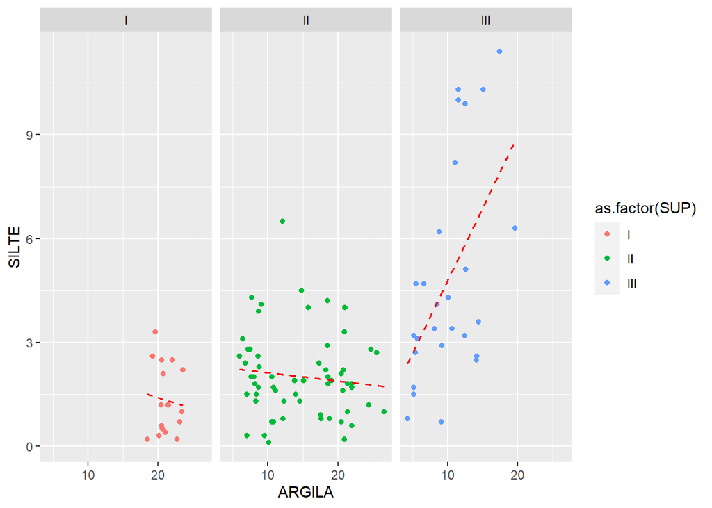

```r
# Gráfico das médias por ano em cada fazenda
dados %>%
  group_by(SUP) %>%
  ggplot(aes(x=ARGILA,y=SILTE,color=as.factor(SUP))) +
  geom_point()+
  facet_wrap(~SUP)+  # scales = "free", se necessário
    geom_smooth(mapping = aes(x=ARGILA, y=SILTE),
              method="lm",
              color="red",lwd=.6,lty=2,
              se=FALSE)
```

**Exercício 24**. Construa o gráfico de distribuição de frequência para as variáveis contínuas do banco de dados.

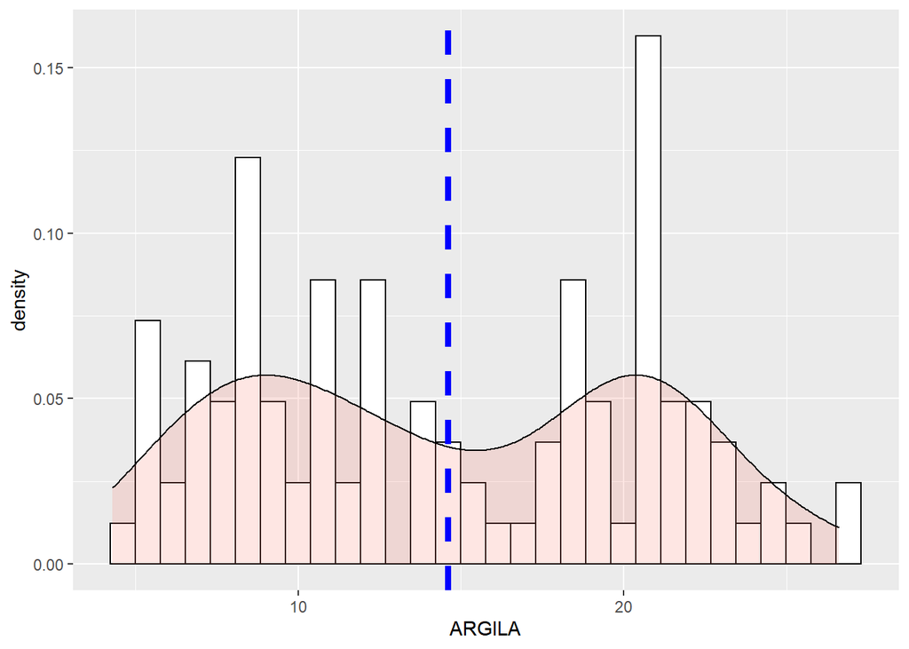

```r
# Hitograma das variáveis contínuas
dados %>%
  group_by(SUP) %>%
  ggplot(aes(x=ARGILA))+
  geom_histogram(aes(y=..density..),color="black",fill="white",bins=30)+
  geom_density(alpha=.2,fill="salmon")+
  geom_vline(aes(xintercept=mean(ARGILA)),color="blue",size=1.6,linetype="dashed")
```

**Exercício 25**. Construa o gráfico de distribuição de frequência para uma variável específica em cada superfície.

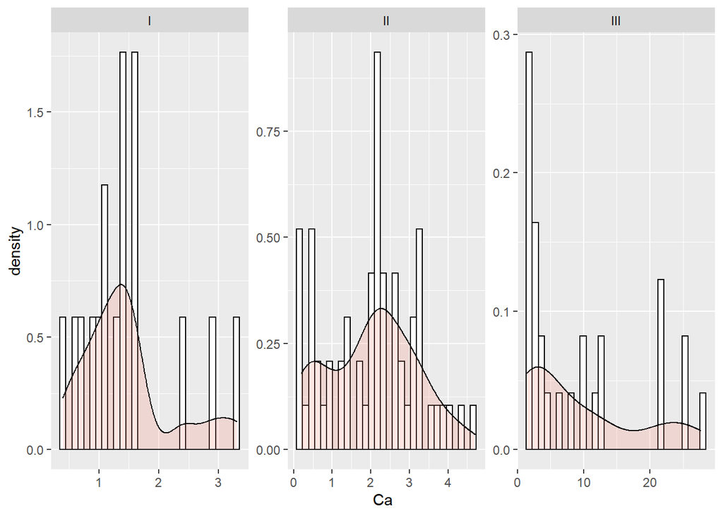

```r
dados %>%
  group_by(SUP) %>%
  ggplot(aes(x=Ca))+
  geom_histogram(aes(y=..density..),color="black",fill="white",bins=30)+
  geom_density(alpha=.2,fill="salmon")+
  facet_wrap(~SUP,scales = "free")
```

## Exemplo de Violin plot

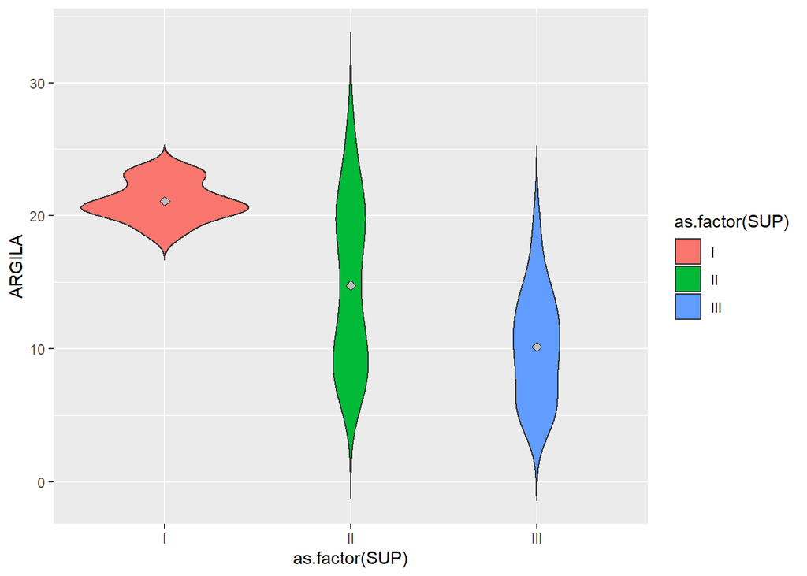

```r
dados %>%
  ggplot(aes(y=ARGILA,x=as.factor(SUP),fill=as.factor(SUP))) +
  geom_violin(trim = FALSE) +
  stat_summary(fun = mean, geom = "point",shape=23,size=2,color="black",fill="gray")
```

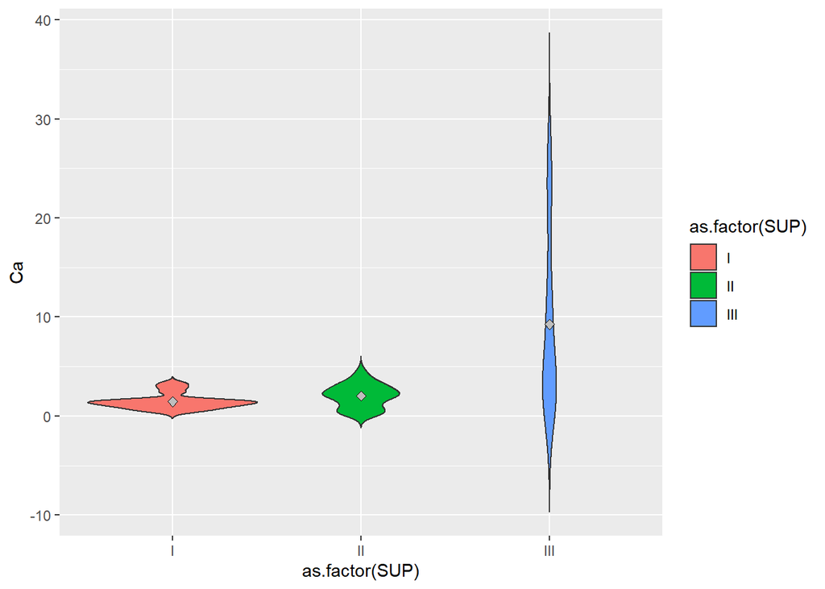

```r
dados %>%
  ggplot(aes(y=Ca,x=as.factor(SUP),fill=as.factor(SUP))) +
  geom_violin(trim = FALSE) +
  stat_summary(fun = mean, geom = "point",shape=23,size=2,color="black",fill="gray")
```

# Alguns testes inferenciais

## Testes de comparação de médias

**Exercício 26**. Verifique se as variâncias do teor de Ca são semelhantes para as superfícies “I” e “II”.

```r
da<-dados %>%
  filter(SUP!="III")
var.test(da$Ca~da$SUP)
```

```
##
##  F test to compare two variances
##
## data:  da$Ca by da$SUP
## F = 0.44261, num df = 16, denom df = 61, p-value = 0.07259
## alternative hypothesis: true ratio of variances is not equal to 1
## 95 percent confidence interval:
##  0.2181266 1.0821862
## sample estimates:
## ratio of variances
##          0.4426101
```

**Exercício 27**. Verifique se as médias do teor de Ca são semelhantes para as superfícies “I” e “II”.

```r
t.test(da$Ca~da$SUP,var.equal=TRUE)
```

```
##
##  Two Sample t-test
##
## data:  da$Ca by da$SUP
## t = -1.8944, df = 77, p-value = 0.06193
## alternative hypothesis: true difference in means is not equal to 0
## 95 percent confidence interval:
##  -1.16841058  0.02913164
## sample estimates:
##  mean in group I mean in group II
##         1.452941         2.022581
```

## Normalidade

**Exercício 28**. Para os dados de Ca para a Superfície “I”, realize o teste de normalidade.

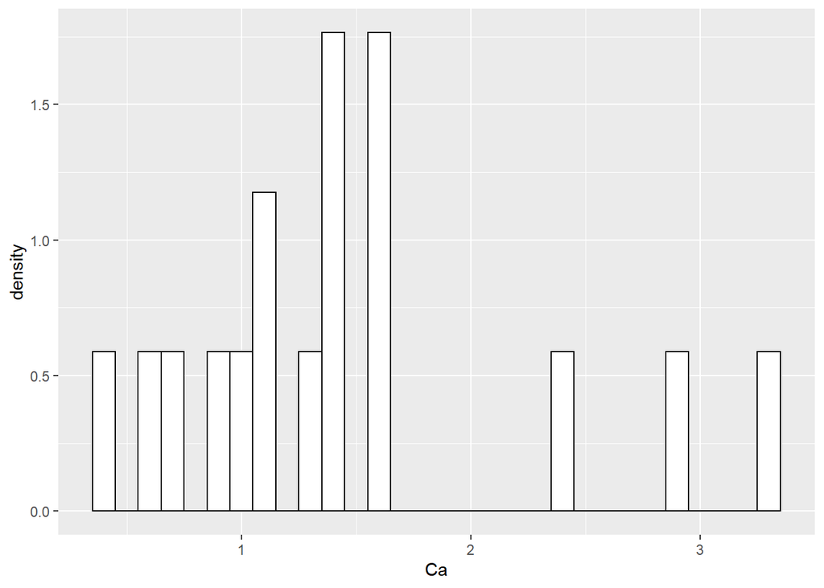

```r
library(nortest)
da<-dados %>%
  filter(SUP=="I")

da %>%
  ggplot(aes(x=Ca)) +
  geom_histogram(aes(y=..density..),color="black",fill="white",bins=30)
```

```r
shapiro.test(da$Ca)
```

```
##
##  Shapiro-Wilk normality test
##
## data:  da$Ca
## W = 0.89246, p-value = 0.05088
```

```r
cvm.test(da$Ca)
```

```
##
##  Cramer-von Mises normality test
##
## data:  da$Ca
## W = 0.13393, p-value = 0.03453
```

```r
lillie.test(da$Ca)
```

```
##
##  Lilliefors (Kolmogorov-Smirnov) normality test
##
## data:  da$Ca
## D = 0.24848, p-value = 0.00647
```

```r
ad.test(da$Ca)
```

```
##
##  Anderson-Darling normality test
##
## data:  da$Ca
## A = 0.75448, p-value = 0.03974
```

## Homocedasticidade e normalidade do erros na Análise de Variância

**Exercício 29**. Realize a ANOVA (análise de variância) para verificar o efeito das superfícies nos teores de ARGILA.

```r
library(lawstat)
mod<-aov(ARGILA~as.factor(SUP),data=dados)
anova(mod)
```

```
## Analysis of Variance Table
##
## Response: ARGILA
##                 Df Sum Sq Mean Sq F value    Pr(>F)
## as.factor(SUP)   2 1255.9  627.93  23.715 3.376e-09 ***
## Residuals      103 2727.3   26.48
## ---
## Signif. codes:  0 '***' 0.001 '**' 0.01 '*' 0.05 '.' 0.1 ' ' 1
```

```r
levene.test(dados$ARGILA,dados$SUP)
```

```
##
##  Modified robust Brown-Forsythe Levene-type test based on the absolute
##  deviations from the median
##
## data:  dados$ARGILA
## Test Statistic = 22.666, p-value = 6.96e-09
```

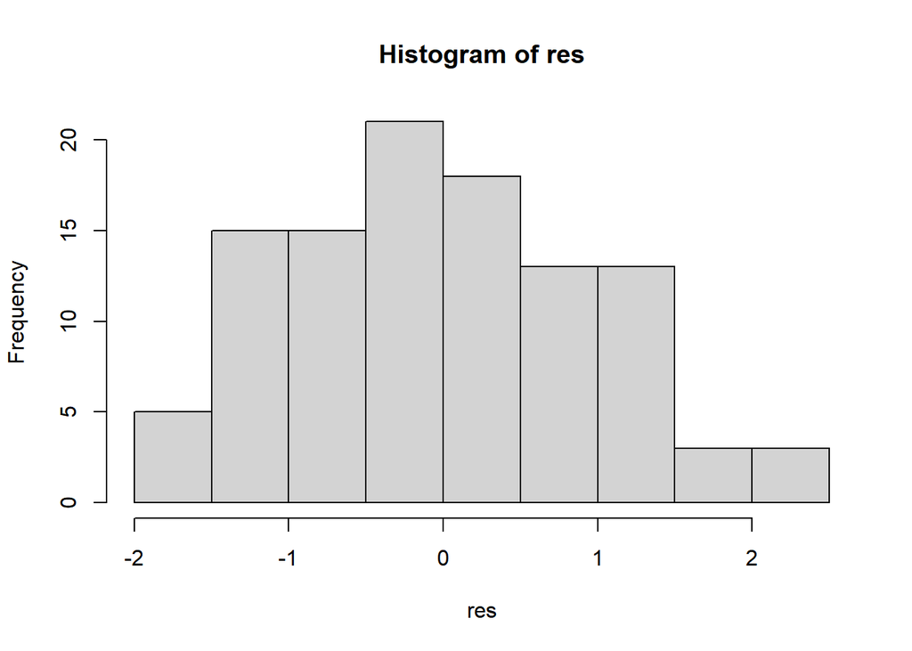

```r
res<-rstudent(mod)
hist(res)
```

```r
shapiro.test(res)
```

```
##
##  Shapiro-Wilk normality test
##
## data:  res
## W = 0.97323, p-value = 0.03052
```

```r
ad.test(res)
```

```
##
##  Anderson-Darling normality test
##
## data:  res
## A = 0.61778, p-value = 0.1052
```

```r
lillie.test(res)
```

```
##
##  Lilliefors (Kolmogorov-Smirnov) normality test
##
## data:  res
## D = 0.072002, p-value = 0.1941
```

```r
cvm.test(res)
```

```
##
##  Cramer-von Mises normality test
##
## data:  res
## W = 0.077302, p-value = 0.2222
```

# Referências

TEETOR, P. R Cookbook. USA: O’Reilly Media, Inc, https://rc2e.com/.